# 基于UNet的图像分割算法模型

## 依赖包导入

```python
import os
import torch
import torch.nn as nn
import torch.optim as optim
import torch.nn.functional as F
from torch.utils.data import Dataset, DataLoader
from torchvision import transforms
import matplotlib.pyplot as plt
import numpy as np
import copy
import cv2
from sklearn.metrics import confusion_matrix
from matplotlib.font_manager import fontManager
from PIL import ImageFilter
from PIL import Image
```

## 解决可视化图像中文乱码问题

```python
from matplotlib.font_manager import fontManager
import os

fonts = [font.name for font in fontManager.ttflist
             if os.path.exists(font.fname) and os.stat(font.fname).st_size>1e6]
print(list(fonts))

# 显示中文,解决图中无法显示中文的问题
plt.rcParams['font.sans-serif']=['KaiTi']

# 设置显示中文后,负号显示受影响。解决坐标轴上乱码问题
plt.rcParams['axes.unicode_minus']=False
```

```
['Calibri', 'STSong', 'HYZhongHei', 'Yu Gothic', 'Calibri', 'Noto Sans SC', 'Ebrima', 'Malgun Gothic', 'SimSun', 'SimSun-ExtG', 'FangSong', 'STXinwei', 'Microsoft YaHei', 'Microsoft JhengHei', 'Segoe UI Variable', 'Cambria', 'STFangsong', 'MS Gothic', 'Calibri', 'Yu Gothic', 'DengXian', 'Malgun Goth…
```

## 1. 数据预处理

### 数据集类

```python
class RetinalDataset(Dataset):
    def __init__(self, img_dir, mask_dir, transform=None):
        self.img_dir = img_dir  # 图像文件夹路径
        self.mask_dir = mask_dir  # 掩码文件夹路径
        self.transform = transform  # 数据变换
        self.images = sorted(os.listdir(img_dir))  # 图像文件列表
        self.masks = sorted(os.listdir(mask_dir))  # 掩码文件列表

    def __len__(self):
        return len(self.images)  # 数据集大小

    def __getitem__(self, idx):
        img_path = os.path.join(self.img_dir, self.images[idx])
        mask_path = os.path.join(self.mask_dir, self.masks[idx])
        image = Image.open(img_path).convert("L")  # 图像转换为灰度图
        mask = Image.open(mask_path).convert("L")  # 掩码转换为灰度图

        image = image.resize((224, 224))  # 调整图像大小
        mask = mask.resize((224, 224))  # 调整掩码大小

        if self.transform:
            image = self.transform(image)  # 应用图像变换
            mask = transforms.ToTensor()(mask)  # 将掩码转换为张量

        return image, mask  # 返回图像和掩码
```

### 数据预处理、数据增强

```python
# 自定义增强对比度和去噪的变换
class ReduceNoise:
    def __call__(self, img):
        # 增加对比度
        img = transforms.functional.adjust_contrast(img, contrast_factor=1.5)

        # 去噪（使用高斯模糊）
        img = img.filter(ImageFilter.GaussianBlur(radius=1))
        return img

data_transforms = {
    'train': transforms.Compose([  # 训练集变换
        transforms.Resize((224, 224)),  # 调整大小
        ReduceNoise(),  # 增加对比度和去噪
        transforms.ToTensor(),  # 转换为张量
        transforms.Normalize(mean=[0.5], std=[0.5])  # 归一化
    ]),
    'val': transforms.Compose([  # 验证集变换
        transforms.Resize((224, 224)),  # 调整大小
        ReduceNoise(),  # 增加对比度和去噪
        transforms.ToTensor(),  # 转换为张量
        transforms.Normalize(mean=[0.5], std=[0.5])  # 归一化
    ])
}
```

### 创建数据集和数据加载器

```python
dataset = RetinalDataset(img_dir='./DME_SegDataset/images', mask_dir='./DME_SegDataset/masks', transform=data_transforms['train'])
train_size = int(0.85 * len(dataset)) # 使用85%作为训练集
val_size = len(dataset) - train_size # 剩下15%作为验证集
train_dataset, val_dataset = torch.utils.data.random_split(dataset, [train_size, val_size])
train_loader = DataLoader(train_dataset, batch_size=4, shuffle=True, drop_last=True)
val_loader = DataLoader(val_dataset, batch_size=4, shuffle=False, drop_last=True)
print(train_size)
print(val_size)
```

```
620
110
```

### 显示随机图像和分割掩码

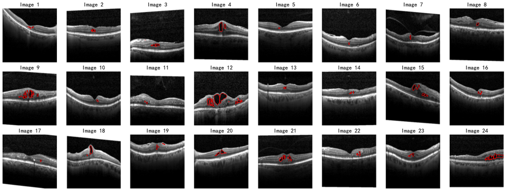

```python
def display(dataset, num_images=24):
    # 从数据集中随机选取样本
    indices = np.random.choice(len(dataset), num_images, replace=False)
    images = []
    masks = []
    for idx in indices:
        img, mask = dataset[idx]
        images.append(img)
        masks.append(mask)

    plt.figure(figsize=(20, 10))

    # 显示图像和掩码
    for i in range(num_images):
        ax = plt.subplot(4, 8, i + 1)
        # 反归一化并转换图像
        image = images[i].numpy().transpose((1, 2, 0))  # 转换到 (H, W, C)
        image = image * np.array([0.5]) + np.array([0.5])  # 反归一化
        image = np.clip(image, 0, 1)  # 限制到0-1
        # 显示图像
        plt.imshow(image, cmap='gray')
        # 显示掩码
        mask = masks[i].numpy().squeeze()
        mask = np.where(mask > 0.5, 1, 0)  # 掩码二值化
        plt.contour(mask, colors='red', levels=[0.5], linewidths=1)
        plt.title(f'Image {i+1}', fontsize=16)
        plt.axis("off")

    plt.tight_layout()
    plt.show()

# 显示随机图像
display(train_dataset, 24)
```

## 2. 创建UNet图像分割模型类

### 下采样以及上采样 为提高模型的戴斯系数，引入注意力机制

```python
class DoubleConv(nn.Module):
    def __init__(self, in_channels, out_channels):
        super().__init__()
        self.double_conv = nn.Sequential(  # 两个卷积块
            nn.Conv2d(in_channels, out_channels, kernel_size=3, padding=1),  # 卷积层
            nn.BatchNorm2d(out_channels),  # 批归一化
            nn.ReLU(inplace=True),  # 激活函数
            nn.Conv2d(out_channels, out_channels, kernel_size=3, padding=1),  # 卷积层
            nn.BatchNorm2d(out_channels),  # 批归一化
            nn.ReLU(inplace=True)  # 激活函数
        )

    def forward(self, x):
        return self.double_conv(x)  # 前向传播

class Down(nn.Module):
    def __init__(self, in_channels, out_channels):
        super().__init__()
        self.maxpool_conv = nn.Sequential(  # 下采样块
            nn.MaxPool2d(2),  # 最大池化
            DoubleConv(in_channels, out_channels)  # 两个卷积
        )

    def forward(self, x):
        return self.maxpool_conv(x)  # 前向传播

class Up(nn.Module):
    def __init__(self, in_channels, out_channels, bilinear=True):
        super().__init__()
        if bilinear:
            self.up = nn.Upsample(scale_factor=2, mode='bilinear', align_corners=True)  # 双线性插值上采样
            self.conv = DoubleConv(in_channels, out_channels)  # 卷积
        else:
            self.up = nn.ConvTranspose2d(in_channels, in_channels // 2, kernel_size=2, stride=2)  # 转置卷积上采样
            self.conv = DoubleConv(in_channels, out_channels)

    def forward(self, x1, x2):
        x1 = self.up(x1)  # 上采样
        diffY = x2.size()[2] - x1.size()[2]  # 计算高度差
        diffX = x2.size()[3] - x1.size()[3]  # 计算宽度差
        x1 = F.pad(x1, [diffX // 2, diffX - diffX // 2, diffY // 2, diffY - diffY // 2])
        x = torch.cat([x2, x1], dim=1)  # 拼接特征图
        return self.conv(x)  # 前向传播

class AttentionGate(nn.Module):
    def __init__(self, in_channels, gating_channels, out_channels):
        super(AttentionGate, self).__init__()
        self.in_channels = in_channels
        self.gating_channels = gating_channels
        self.out_channels = out_channels

        self.theta = nn.Conv2d(in_channels, out_channels, kernel_size=1)
        self.phi = nn.Conv2d(gating_channels, out_channels, kernel_size=1)
        self.psi = nn.Conv2d(out_channels, out_channels, kernel_size=1)

        self.relu = nn.ReLU(inplace=True)
        self.sigmoid = nn.Sigmoid()

    def forward(self, x, g):
        # x g的尺寸要一致
        if x.size() != g.size():
            g = F.interpolate(g, size=x.size()[2:], mode='bilinear', align_corners=True)

        theta_x = self.theta(x)
        phi_g = self.phi(g)
        f = theta_x + phi_g
        f = self.relu(f)
        psi_f = self.psi(f)
        attn = self.sigmoid(psi_f)
        return x * attn

class OutConv(nn.Module):
    def __init__(self, in_channels, out_channels):
        super(OutConv, self).__init__()
        self.conv = nn.Conv2d(in_channels, out_channels, kernel_size=1)  # 1x1卷积

    def forward(self, x):
        return self.conv(x)  # 前向传播

class AttentionUNet(nn.Module):
    def __init__(self, n_channels=1, n_classes=1, bilinear=True):
        super(AttentionUNet, self).__init__()
        self.n_channels = n_channels
        self.n_classes = n_classes
        self.bilinear = bilinear

        self.inc = DoubleConv(n_channels, 64)
        self.down1 = Down(64, 128)
        self.down2 = Down(128, 256)
        self.down3 = Down(256, 512)
        self.down4 = Down(512, 1024)

        self.up1 = Up(1024 + 512, 512, bilinear)
        self.up2 = Up(512 + 256, 256, bilinear)
        self.up3 = Up(256 + 128, 128, bilinear)
        self.up4 = Up(128 + 64, 64, bilinear)

        # 注意力机制
        self.att1 = AttentionGate(512, 1024, 512)
        self.att2 = AttentionGate(256, 512, 256)
        self.att3 = AttentionGate(128, 256, 128)
        self.att4 = AttentionGate(64, 128, 64)

        self.outc = OutConv(64, n_classes)

    def forward(self, x):
        x1 = self.inc(x)
        x2 = self.down1(x1)
        x3 = self.down2(x2)
        x4 = self.down3(x3)
        x5 = self.down4(x4)

        x = self.up1(x5, x4)
        x = self.up2(self.att1(x, x5), x3)
        x = self.up3(self.att2(x, x4), x2)
        x = self.up4(self.att3(x, x3), x1)

        logits = self.outc(x)
        return torch.sigmoid(logits)
```

### 初始化模型、损失函数和优化器

```python
device = torch.device('cuda' if torch.cuda.is_available() else 'cpu')
model = AttentionUNet().to(device)
criterion = nn.BCELoss()
optimizer = optim.Adam(model.parameters(), lr=1e-4)
scheduler = optim.lr_scheduler.ReduceLROnPlateau(optimizer, mode='min', factor=0.1, patience=5, verbose=True)
```

```python
# Dice系数计算
def dice_acc(preds, targets):
    smooth = 1e-7  # 平滑项
    intersection = (preds * targets).sum()  # 计算交集
    return (2. * intersection + smooth) / (preds.sum() + targets.sum() + smooth)  # 计算Dice系数
```

## 3. 模型训练

### 模型训练函数

```python
def train_model(model, dataloaders, criterion, optimizer, num_epochs=25, patience=3):
    history = {
        'train_loss': [],
        'val_loss': [],
        'train_dice': [],
        'val_dice': []
    }
    best_model_wts = copy.deepcopy(model.state_dict())  # 保存最佳模型权重
    best_val_loss = float('inf')
    # 早停机制
    counter = 0  # 耐心值计数器

    for epoch in range(num_epochs):
        print(f'Epoch {epoch + 1}/{num_epochs}')
        print('-' * 10)

        for phase in ['train', 'val']:
            if phase == 'train':
                model.train()  # 训练模式
            else:
                model.eval()  # 验证模式

            running_loss = 0.0
            running_dice = 0.0

            for inputs, masks in dataloaders[phase]:
                inputs = inputs.to(device)
                masks = masks.to(device)

                optimizer.zero_grad()  # 梯度清零

                with torch.set_grad_enabled(phase == 'train'):
                    outputs = model(inputs)  # 模型输出
                    loss = criterion(outputs, masks)  # 计算损失
                    preds = (outputs > 0.5).float()  # 生成预测掩码

                    if phase == 'train':
                        loss.backward()  # 反向传播
                        optimizer.step()  # 更新权重

                running_loss += loss.item() * inputs.size(0)
                dice = dice_acc(preds, masks)  # 计算Dice系数
                running_dice += dice.item() * inputs.size(0)  # 累计Dice系数

            epoch_loss = running_loss / len(dataloaders[phase].dataset)  # 计算平均损失
            epoch_dice = running_dice / len(dataloaders[phase].dataset)  # 计算平均Dice系数

            print(f'{phase} Loss: {epoch_loss:.4f} Dice: {epoch_dice:.4f}')

            if phase == 'train':
                history['train_loss'].append(epoch_loss)
                history['train_dice'].append(epoch_dice)
            else:
                history['val_loss'].append(epoch_loss)
                history['val_dice'].append(epoch_dice)

                if epoch_loss < best_val_loss:
                    best_val_loss = epoch_loss
                    best_model_wts = copy.deepcopy(model.state_dict())  # 保存最佳模型权重
                    counter = 0  # 重置计数器
                else:
                    counter += 1  # 增加计数器

        scheduler.step(history['val_loss'][-1])
        print()

        if counter >= patience:
            print(f'Early stopping at epoch {epoch + 1}')
            break

    print('Best val Loss: {:4f}'.format(best_val_loss))
    model.load_state_dict(best_model_wts)  # 加载最佳模型权重
    return model, history
```

### 模型训练

```python
dataloaders = {'train': train_loader, 'val': val_loader}
model, history = train_model(model, dataloaders, criterion, optimizer, num_epochs=25, patience=3)
```

```
----------
train Loss: 0.3018 Dice: 0.3472
val Loss: 0.2442 Dice: 0.5886

----------
train Loss: 0.1932 Dice: 0.6893
val Loss: 0.1692 Dice: 0.5226

----------
train Loss: 0.1376 Dice: 0.7441
val Loss: 0.1164 Dice: 0.7272

----------
train Loss: 0.1025 Dice: 0.7759
val Loss: 0.0870 Dice: 0.7565

----------
train Loss: 0.0785 Dice: 0.7821
val Loss: 0.0669 Dice: 0.7527

----------
train Loss: 0.0617 Dice: 0.8025
val Loss: 0.0540 Dice: 0.7647

----------
train Loss: 0.0497 Dice: 0.8049
val Loss: 0.0416 Dice: 0.7729

----------
train Loss: 0.0409 Dice: 0.8073
val Loss: 0.0381 Dice: 0.7641

----------
train Loss: 0.0339 Dice: 0.8138
val Loss: 0.0313 Dice: 0.7897

----------
train Loss: 0.0285 Dice: 0.8227
val Loss: 0.0256 Dice: 0.7946

```

[output cut: 46 more lines]

```
val Loss: 0.0080 Dice: 0.8081

----------
train Loss: 0.0074 Dice: 0.8420
val Loss: 0.0077 Dice: 0.8033

----------
train Loss: 0.0069 Dice: 0.8474
val Loss: 0.0072 Dice: 0.8087

----------
train Loss: 0.0065 Dice: 0.8505
val Loss: 0.0068 Dice: 0.8113

Best val Loss: 0.006792
```

### 保存模型

```python
torch.save(model.state_dict(), 'UNet_model.pth')  # 保存模型权重
```

## 4. 模型评估

### 模型metric绘制

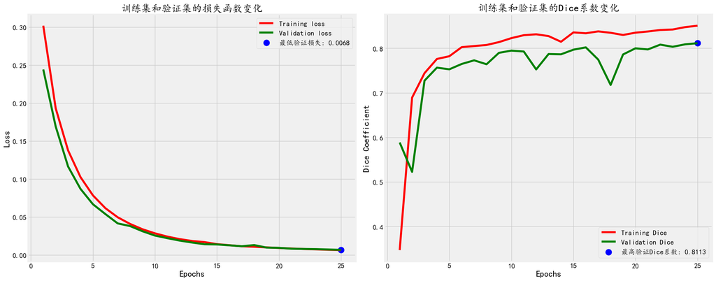

```python
# Plot training history
plt.figure(figsize=(20, 8))
plt.style.use('fivethirtyeight')

# 定义训练和验证的损失及Dice系数数据
Epochs = range(1, len(history['train_loss']) + 1)
tr_loss = history['train_loss']
val_loss = history['val_loss']
tr_dice = history['train_dice']
val_dice = history['val_dice']

index_loss = val_loss.index(min(val_loss))
val_lowest = min(val_loss)
loss_label = f'最低验证损失: {val_lowest:.4f}'

index_dice = val_dice.index(max(val_dice))
dice_highest = max(val_dice)
dice_label = f'最高验证Dice系数: {dice_highest:.4f}'

# 绘制训练和验证的损失图
plt.subplot(1, 2, 1)
plt.plot(Epochs, tr_loss, 'r', label='Training loss')
plt.plot(Epochs, val_loss, 'g', label='Validation loss')
plt.scatter(index_loss + 1, val_lowest, s=150, c='blue', label=loss_label)
plt.title('训练集和验证集的损失函数变化')
plt.xlabel('Epochs')
plt.ylabel('Loss')
plt.legend()

# 绘制训练和验证的Dice系数图
plt.subplot(1, 2, 2)
plt.plot(Epochs, tr_dice, 'r', label='Training Dice')
plt.plot(Epochs, val_dice, 'g', label='Validation Dice')
plt.scatter(index_dice + 1, dice_highest, s=150, c='blue', label=dice_label)
plt.title('训练集和验证集的Dice系数变化')
plt.xlabel('Epochs')
plt.ylabel('Dice Coefficient')
plt.legend()

plt.tight_layout()
plt.show()
```

### Dice系数以及IOU交并集计算

Dice系数（Dice coefficient）和IOU（Intersection over Union）是两种广泛应用于计算机视觉和图像分割任务中的相似度指标。  
Dice系数是一种基于像素级别的相似度度量，通常用于比较两个二进制图像的相似程度。它计算两个集合之间的相似度，即预测结果和真实标签之间的相似度，其计算公式如下： Dice系数 = 2 * TP / (2 * TP + FP + FN)  
其中，TP（True Positive）表示预测为正样本且标签为正样本的像素数量，FP（False Positive）表示预测为正样本但标签为负样本的像素数量，FN（False Negative）表示预测为负样本但标签为正样本的像素数量。Dice系数的取值范围在0到1之间，其值越接近1，表示预测结果与真实标签的重叠度越高，相似度越高。

而IOU是一种广泛用于目标检测和语义分割中的指标，它表示预测结果与真实标签的交集与并集之比，其计算公式如下：IOU = TP / (TP + FP + FN)  
与Dice系数类似，IOU的取值范围也在0到1之间，其值越接近1，表示预测结果与真实标签的重叠度越高，相似度越高。

需要注意的是，Dice系数和IOU的计算方式略有不同，但它们的主要区别在于Dice系数对预测结果和真实标签的交集和并集的贡献是相等的，而IOU更加关注预测结果与真实标签的交集。因此，Dice系数更加敏感于小目标，而IOU则更加适用于大目标的检测和分割任务。

```python
model.eval()  # 设置为评估模式
dice_list = []  # 存储Dice系数
iou_list = []  # 存储IoU

# IoU计算
def iou_acc(preds, targets):
    smooth = 1e-7  # 平滑项
    intersection = (preds * targets).sum()  # 计算交集
    union = preds.sum() + targets.sum() - intersection  # 计算并集
    return (intersection + smooth) / (union + smooth)  # 计算IoU

with torch.no_grad():
    for inputs, masks in val_loader:
        inputs = inputs.to(device)
        masks = masks.to(device)
        outputs = model(inputs)  # 模型输出
        preds = (outputs > 0.5).float()  # 生成预测掩码
        dice = dice_acc(preds, masks)  # 计算Dice系数
        iou = iou_acc(preds, masks)  # 计算IoU
        dice_list.append(dice.item())
        iou_list.append(iou.item())

print(f'Average Dice Coefficient: {np.mean(dice_list):.4f}')
print(f'Average IoU: {np.mean(iou_list):.4f}')
```

```
Average Dice Coefficient: 0.8263
Average IoU: 0.7085
```

## 5.图像配准

```python
def registration(ori_img, seg_img):
    # 转换为灰度图像
    ori_gray = cv2.cvtColor(ori_img, cv2.COLOR_BGR2GRAY)
    seg_gray = cv2.cvtColor(seg_img, cv2.COLOR_BGR2GRAY)

    # 使用ORB算法提取特征点
    orb = cv2.ORB_create()
    keypoints1, descriptors1 = orb.detectAndCompute(ori_gray, None)
    keypoints2, descriptors2 = orb.detectAndCompute(seg_gray, None)

    # 使用BFMatcher匹配器进行特征点匹配
    bf = cv2.BFMatcher(cv2.NORM_HAMMING, crossCheck=True)
    matches = bf.match(descriptors1, descriptors2)

    # 按距离排序匹配点
    matches = sorted(matches, key=lambda x: x.distance)

    # 筛选匹配点
    good_matches = matches[:50]  # 选择前50个匹配点

    # 检查匹配点数量是否足够
    if len(good_matches) < 4:
        print(f"匹配点数量不足: {len(good_matches)}")
        return None

    # 提取匹配点的坐标
    src_pts = np.float32([keypoints1[m.queryIdx].pt for m in good_matches]).reshape(-1, 1, 2)
    dst_pts = np.float32([keypoints2[m.trainIdx].pt for m in good_matches]).reshape(-1, 1, 2)

    # 计算几何变换矩阵
    M, mask = cv2.findHomography(dst_pts, src_pts, cv2.RANSAC, 5.0)

    # 检查变换矩阵是否有效
    if M is None or M.shape != (3, 3):
        print("变换矩阵无效")
        return None

    # 应用几何变换进行图像配准
    img = cv2.warpPerspective(seg_img, M, (ori_img.shape[1], ori_img.shape[0]))

    return img
```

### 显示配准后的图像

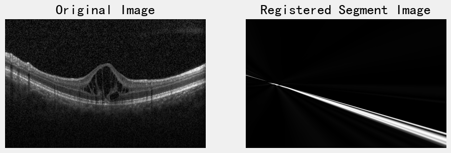

```python
# 加载原始图像和分割后的图像
ori_img = cv2.imread('./static/img/segment_test/DME-3722280-1.jpeg')
seg_img = cv2.imread('./static/img/segment_test/mask_DME-3722280-1.jpeg')

# 进行图像配准
img = registration(ori_img, seg_img)

# 显示配准后的图像
if img is not None:
    plt.figure(figsize=(10, 5))
    plt.subplot(1, 2, 1)
    plt.imshow(cv2.cvtColor(ori_img, cv2.COLOR_BGR2RGB))
    plt.title('Original Image')
    plt.axis('off')

    plt.subplot(1, 2, 2)
    plt.imshow(cv2.cvtColor(img, cv2.COLOR_BGR2RGB))
    plt.title('Registered Segment Image')
    plt.axis('off')

    plt.show()
else:
    print("图像配准失败")
```

从配准结果来看，配准后的图像出现了明显的错位和模糊，下面是可能的原因：

1. 匹配点不足或质量不佳 在计算几何变换矩阵时，如果匹配的特征点数量不足或质量不高，可能导致计算出的变换矩阵不准确，从而导致配准失败。
2. 特征提取和匹配问题 使用的特征提取算法（如ORB）可能在某些图像上表现不佳，尤其是在图像对比度低、纹理不明显或存在噪声的情况下。
3. 几何变换模型不适用 在某些情况下，使用仿射变换或投影变换可能无法准确描述图像之间的几何关系。